# Data visualsation project using Bike trips (San Francisco)

## Bivariate Exploration

> In this section, investigate relationships between pairs of variables in your data. Make sure the variables that you cover here have been introduced in some fashion in the previous section (univariate exploration).

```python
bikes_clean.info()
```

```
<class 'pandas.core.frame.DataFrame'>
Int64Index: 174363 entries, 4 to 183411
Data columns (total 23 columns):
 #   Column                   Non-Null Count   Dtype
---  ------                   --------------   -----
 0   duration_sec             174363 non-null  int64
 1   start_time               174363 non-null  datetime64[ns]
 2   end_time                 174363 non-null  datetime64[ns]
 3   start_station_id         174363 non-null  float64
 4   start_station_name       174363 non-null  object
 5   start_station_latitude   174363 non-null  float64
 6   start_station_longitude  174363 non-null  float64
 7   end_station_id           174363 non-null  float64
 8   end_station_name         174363 non-null  object
 9   end_station_latitude     174363 non-null  float64
 10  end_station_longitude    174363 non-null  float64
 11  bike_id                  174363 non-null  int64
 12  user_type                174363 non-null  object
 13  member_birth_year        174363 non-null  int32
 14  member_gender            174363 non-null  object
 15  bike_share_for_all_trip  174363 non-null  object
 16  start_dayofweek          174363 non-null  category
 17  start_time_hour          174363 non-null  int64
 18  end_dayofweek            174363 non-null  category
 19  end_time_hour            174363 non-null  int64
 20  duration_min             174363 non-null  float64
 21  duration_hour            174363 non-null  float64
 22  user_age                 174363 non-null  int32
dtypes: category(2), datetime64[ns](2), float64(8), int32(2), int64(4), object(5)
memory usage: 33.3+ MB
```

We will be using different types of variables for different plots so lets encode this first.

```python
# encoding variable names
numeric_vars_all = ['duration_sec', 'start_time', 'end_time', 'start_station_id', 'start_station_latitude', 'start_station_longitude', 'end_station_id', 'end_station_latitude',
'end_station_longitude', 'bike_id', 'member_birth_year', 'user_age', 'duration_min', 'duration_hour']
numeric_vars = ['duration_min', 'user_age']
# These numeric variables were identified as our key variables
categoric_vars = ['start_dayofweek', 'start_time_hour', 'member_gender', 'user_type']
```

Lets look at a very general overview of potential relationships between the numeric variables using a heatmap

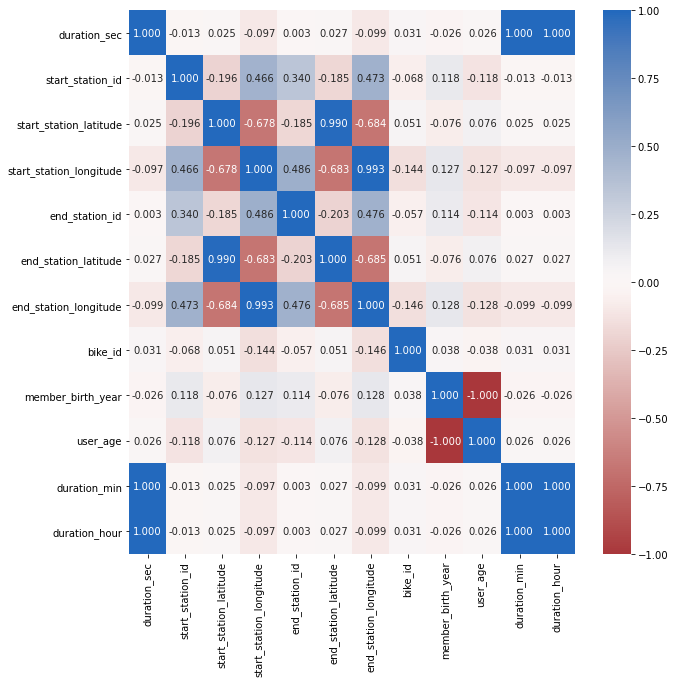

```python
plt.figure(figsize = [10, 10])
sns.heatmap(bikes_clean[numeric_vars_all].corr(), annot = True, fmt = '.3f', cmap = 'vlag_r', center = 0);
# Returns a heatmap with Pearson correlation values
```

Generally the correlations are quite weak, however strong ones are seen by duration_min and duration_hour, but these are essentially the same value, but in different units.

Lets look in more detail at our key variables of interest, age and duration

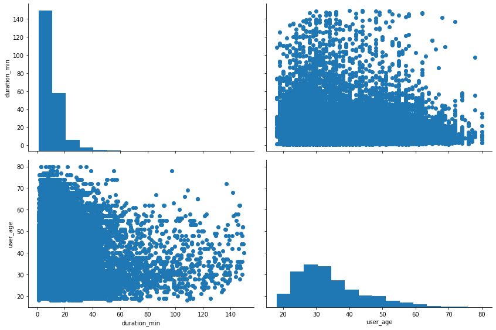

```python
g = sns.PairGrid(data = bikes_clean, vars = numeric_vars, height = 4, aspect = 1.5)
g = g.map_diag(plt.hist, bins = 15);
g.map_offdiag(plt.scatter);
# Loot at our variables of interest in more detail, namely age and duration
# We have potted too many points, lets look at at resolving some of these issues with scatter plots
```

We can see that the relationsips between these two variables are quite weak, however given that there is a lot of data present above, it would be best to add some transparency into our visualsation to identify any trends

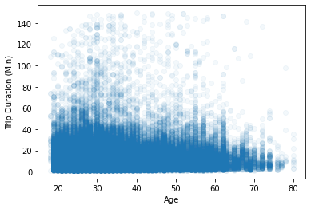

```python
plt.scatter(data=bikes_clean, x='user_age', y='duration_min', alpha=1/20)
plt.xlabel('Age')
plt.ylabel('Trip Duration (Min)');
```

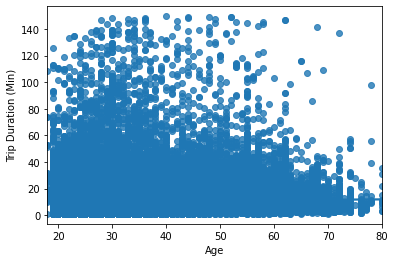

```python
sns.regplot(data=bikes_clean, x='user_age', y='duration_min')
plt.xlabel('Age')
plt.ylabel('Trip Duration (Min)');
# Our regression didnt work for this.
```

Using transparancy and regression line didnt really work, there is no real relationship present.

However, most users of the same ages have short bike trips (less than 40 minutes) and as users get older, there are less longer trips. However this could have been a selection bias for users who would actually use this service and may not represent the population.

Lets look at days of week again, as that looked really interesting in the univariate exploration. Lets add gender as another variable to explore the days of the week

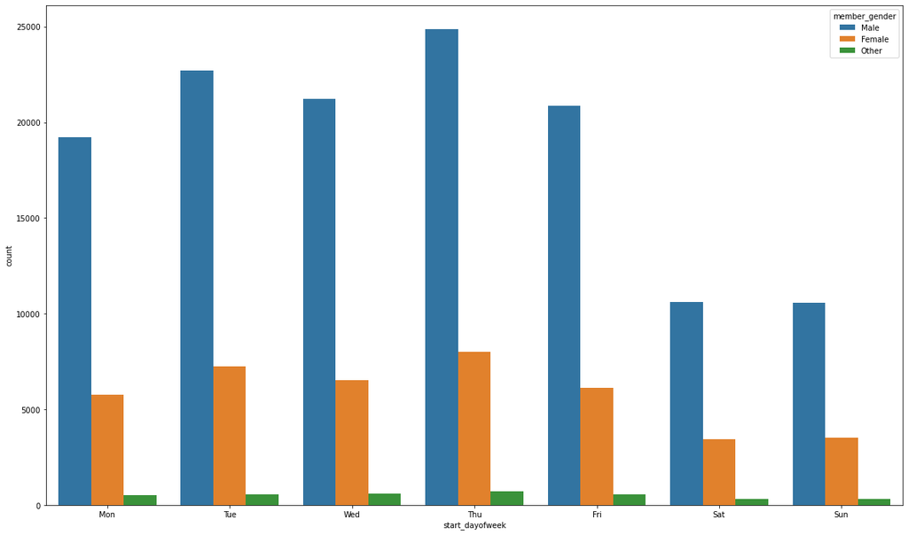

```python
plt.figure(figsize = [20, 12]);
sns.countplot(data = bikes_clean, x = 'start_dayofweek', hue = 'member_gender');
# Using a bargraph we can see that on weekends less females compared to males use the serive, is this trend similar with time of the day I wonder
```

There is a differce between the genders, females tend to cycle less on weekends compared to males. Lets see if this relationship is present with the hours of the day

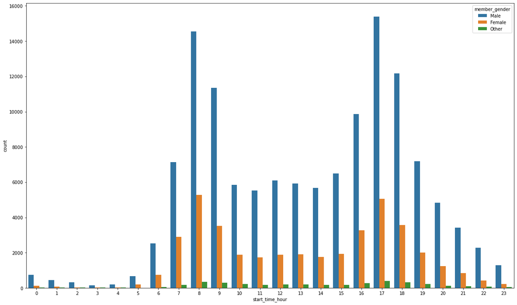

```python
plt.figure(figsize = [20, 12]);
sns.countplot(data = bikes_clean, x = 'start_time_hour', hue = 'member_gender');
# interesting, a lot less females use this sevice compared to males. However it must be remembered that a lot more males are subscribeld to this service.
```

Lets look at subscribles and hours next

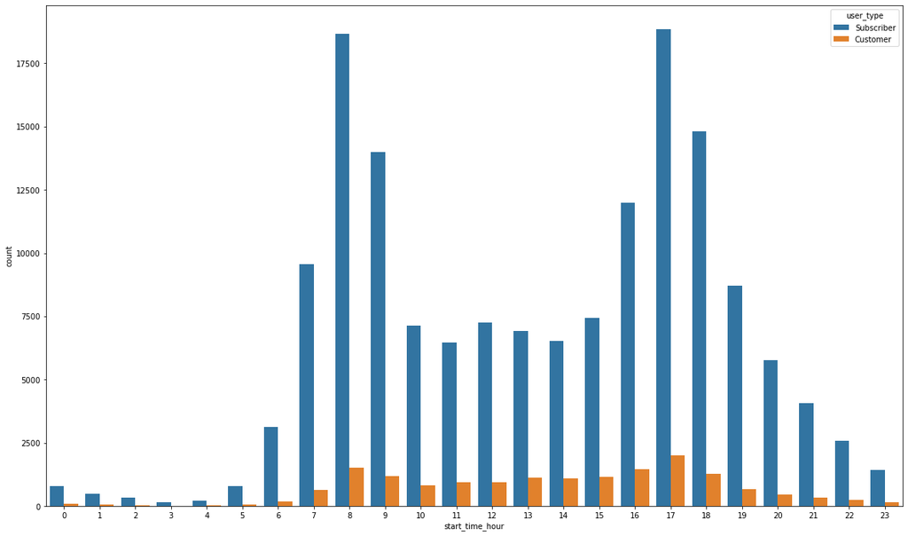

```python
plt.figure(figsize = [20, 12]);
sns.countplot(data = bikes_clean, x = 'start_time_hour', hue = 'user_type');
# both subscribers and customers have similar treends to time of day
```

Lets look at time of day and days of week so see any difference in times and days of the week.

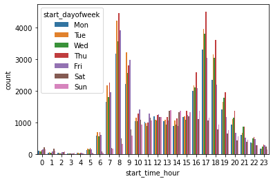

```python
sns.countplot(data = bikes_clean, x = 'start_time_hour', hue = 'start_dayofweek');
# While the subsriber count changes on different days, generally the customer numbers remain stable throughout the week.
# Overall plot is hard to read, lets change a few things to make it more readable as a visual
```

The previous visual was hard to read, lets clean it up a bit

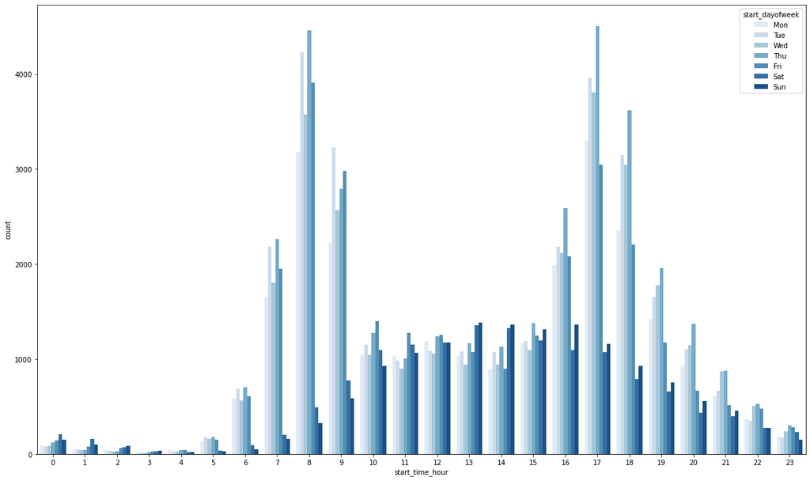

```python
plt.figure(figsize = [20, 12]);
sns.countplot(data = bikes_clean, x = 'start_time_hour', hue = 'start_dayofweek', palette = 'Blues');
# While the subsriber count changes on different days, generally the customer numbers remain stable throughout the wekk
```

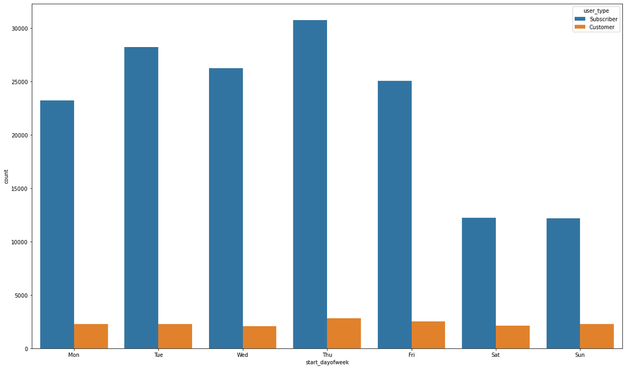

```python
plt.figure(figsize = [20, 12]);
sns.countplot(data = bikes_clean, x = 'start_dayofweek', hue = 'user_type');
```

Lets look at a spatial aspect in a basic manner using the lat and long info.

```python
bikes_clean.info()
```

```
<class 'pandas.core.frame.DataFrame'>
Int64Index: 174363 entries, 4 to 183411
Data columns (total 23 columns):
 #   Column                   Non-Null Count   Dtype
---  ------                   --------------   -----
 0   duration_sec             174363 non-null  int64
 1   start_time               174363 non-null  datetime64[ns]
 2   end_time                 174363 non-null  datetime64[ns]
 3   start_station_id         174363 non-null  float64
 4   start_station_name       174363 non-null  object
 5   start_station_latitude   174363 non-null  float64
 6   start_station_longitude  174363 non-null  float64
 7   end_station_id           174363 non-null  float64
 8   end_station_name         174363 non-null  object
 9   end_station_latitude     174363 non-null  float64
 10  end_station_longitude    174363 non-null  float64
 11  bike_id                  174363 non-null  int64
 12  user_type                174363 non-null  object
 13  member_birth_year        174363 non-null  int32
 14  member_gender            174363 non-null  object
 15  bike_share_for_all_trip  174363 non-null  object
 16  start_dayofweek          174363 non-null  category
 17  start_time_hour          174363 non-null  int64
 18  end_dayofweek            174363 non-null  category
 19  end_time_hour            174363 non-null  int64
 20  duration_min             174363 non-null  float64
 21  duration_hour            174363 non-null  float64
 22  user_age                 174363 non-null  int32
dtypes: category(2), datetime64[ns](2), float64(8), int32(2), int64(4), object(5)
memory usage: 33.3+ MB
```

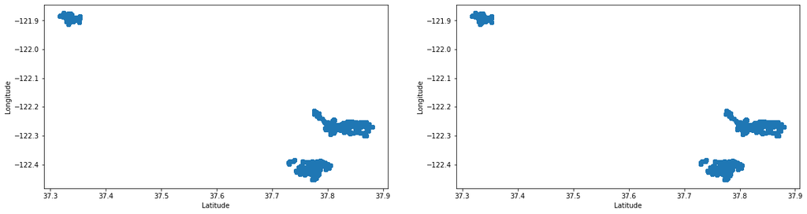

```python
plt.figure(figsize = [20, 5])

plt.subplot(1, 2, 1)
plt.scatter(data = bikes_clean, x = 'start_station_latitude', y = 'start_station_longitude');
plt.xlabel('Latitude')
plt.ylabel('Longitude');

plt.subplot(1, 2, 2)
plt.scatter(data = bikes_clean, x = 'end_station_latitude', y = 'end_station_longitude');
plt.xlabel('Latitude')
plt.ylabel('Longitude');
```

Looking at the data spatially in a very basic format, we can see that there are three main clusters of stations and is not spread out enough for us to explore further. Given that we had a spatial element to this data it is a pity it didnt work out.

### Did you observe any interesting relationships between the other features (not the main feature(s) of interest)?

- Generally, less females use this service at weekends compared to males in addition to the nighttime hours, i.e. 12am-6am.

## Multivariate Exploration

> Create plots of three or more variables to investigate your data even further. Make sure that your investigations are justified, and follow from your work in the previous sections.

```python
bikes_clean.info()
```

```
<class 'pandas.core.frame.DataFrame'>
Int64Index: 174363 entries, 4 to 183411
Data columns (total 23 columns):
 #   Column                   Non-Null Count   Dtype
---  ------                   --------------   -----
 0   duration_sec             174363 non-null  int64
 1   start_time               174363 non-null  datetime64[ns]
 2   end_time                 174363 non-null  datetime64[ns]
 3   start_station_id         174363 non-null  float64
 4   start_station_name       174363 non-null  object
 5   start_station_latitude   174363 non-null  float64
 6   start_station_longitude  174363 non-null  float64
 7   end_station_id           174363 non-null  float64
 8   end_station_name         174363 non-null  object
 9   end_station_latitude     174363 non-null  float64
 10  end_station_longitude    174363 non-null  float64
 11  bike_id                  174363 non-null  int64
 12  user_type                174363 non-null  object
 13  member_birth_year        174363 non-null  int32
 14  member_gender            174363 non-null  object
 15  bike_share_for_all_trip  174363 non-null  object
 16  start_dayofweek          174363 non-null  category
 17  start_time_hour          174363 non-null  int64
 18  end_dayofweek            174363 non-null  category
 19  end_time_hour            174363 non-null  int64
 20  duration_min             174363 non-null  float64
 21  duration_hour            174363 non-null  float64
 22  user_age                 174363 non-null  int32
dtypes: category(2), datetime64[ns](2), float64(8), int32(2), int64(4), object(5)
memory usage: 33.3+ MB
```

Lets look at days of week and the different user types with the different genders. We want to do this as we would like to know if the same trend of less users at weekend as seen in bivariate exploration is present within a multivariate exploration

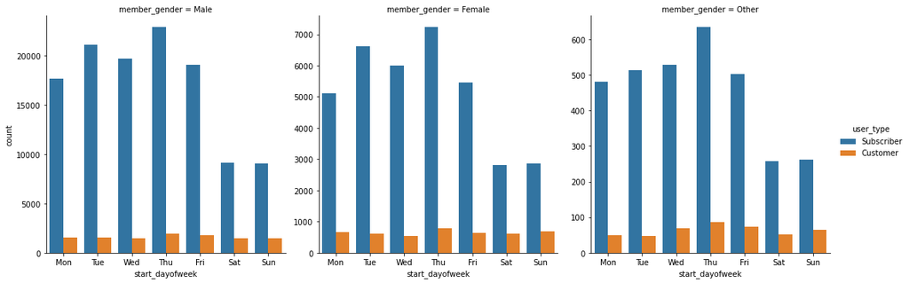

```python
sns.catplot(data=bikes_clean, x='start_dayofweek', col='member_gender',hue='user_type',kind='count', order= weekdays, sharey=False);
```

This plot is separating the different genders and different users throughout the week. Even though the counts are different, the subscribers have a similar patter of using the bikes less on the weekend, but this multivariate plots shows us like he bivariate plot that customers generally keep using the service thoughout the week. Their useage does not decrease with the weekend.

This is interesting as subscribers use this service less on weekends, but still pay for it. Let's explore this visual a bit more with days of week and users.

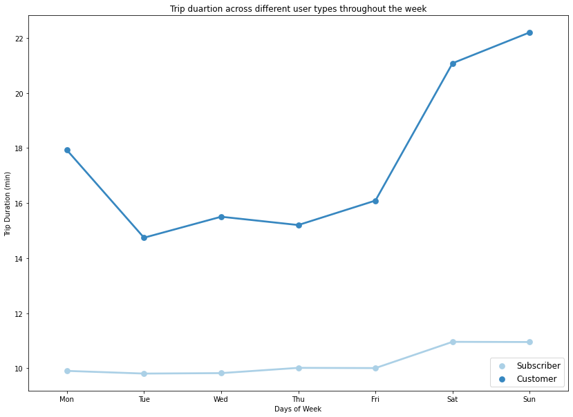

```python
fig = plt.figure(figsize = [14,10])
sns.pointplot(data = bikes_clean, x = 'start_dayofweek', y = 'duration_min', hue = 'user_type', palette = 'Blues', ci=None)
plt.title('Trip duartion across different user types throughout the week')
plt.ylabel('Trip Duration (min)')
plt.xlabel('Days of Week')
plt.legend(loc=4, prop={'size': 12})
plt.show();
```

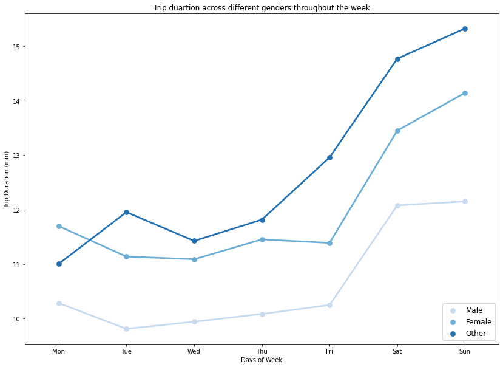

```python
fig = plt.figure(figsize = [14,10])
sns.pointplot(data = bikes_clean, x = 'start_dayofweek', y = 'duration_min', hue = 'member_gender', palette = 'Blues', ci=None)
plt.title('Trip duartion across different genders throughout the week')
plt.ylabel('Trip Duration (min)')
plt.xlabel('Days of Week')
plt.legend(loc=4, prop={'size': 12})
plt.show();
```

Wow, so this is neat, so while subscribers use the service less on weekends, their actual trip durations actually increase during the weekend. This is also seen with customers. However overall their trip lengths are shorter.

```python
bikes_clean.info()
```

```
<class 'pandas.core.frame.DataFrame'>
Int64Index: 174363 entries, 4 to 183411
Data columns (total 23 columns):
 #   Column                   Non-Null Count   Dtype
---  ------                   --------------   -----
 0   duration_sec             174363 non-null  int64
 1   start_time               174363 non-null  datetime64[ns]
 2   end_time                 174363 non-null  datetime64[ns]
 3   start_station_id         174363 non-null  float64
 4   start_station_name       174363 non-null  object
 5   start_station_latitude   174363 non-null  float64
 6   start_station_longitude  174363 non-null  float64
 7   end_station_id           174363 non-null  float64
 8   end_station_name         174363 non-null  object
 9   end_station_latitude     174363 non-null  float64
 10  end_station_longitude    174363 non-null  float64
 11  bike_id                  174363 non-null  int64
 12  user_type                174363 non-null  object
 13  member_birth_year        174363 non-null  int32
 14  member_gender            174363 non-null  object
 15  bike_share_for_all_trip  174363 non-null  object
 16  start_dayofweek          174363 non-null  category
 17  start_time_hour          174363 non-null  int64
 18  end_dayofweek            174363 non-null  category
 19  end_time_hour            174363 non-null  int64
 20  duration_min             174363 non-null  float64
 21  duration_hour            174363 non-null  float64
 22  user_age                 174363 non-null  int32
dtypes: category(2), datetime64[ns](2), float64(8), int32(2), int64(4), object(5)
memory usage: 33.3+ MB
```

Lets look at some of the nuremic varialbes using the pair grids, namely with our varibles of interst.

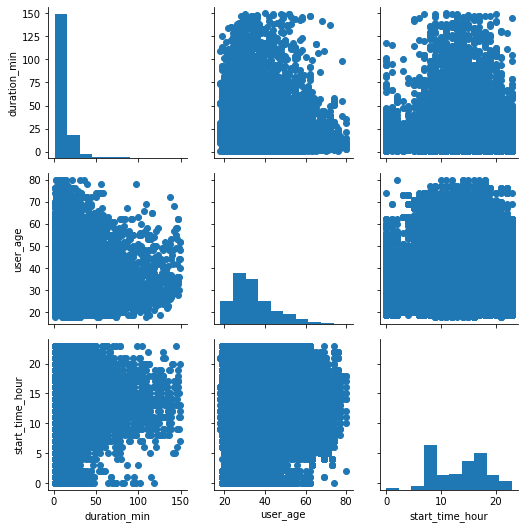

```python
bikes = ['duration_min', 'user_age', 'start_time_hour']
g = sns.PairGrid(data = bikes_clean, vars = bikes)
g = g.map_offdiag(plt.scatter);
g.map_diag(plt.hist);
```

This multivariate explortation of our key variables using a pair grid didnt offer more insight as compared to the bivariate visualisation.

### Were there any interesting or surprising interactions between features?

- While bike ride counts went down during the weekend, ride duration increased. This was only seen though multivariate visualisation.

> At the end of your report, make sure that you export the notebook as an html file from the `File > Download as... > HTML` menu. Make sure you keep track of where the exported file goes, so you can put it in the same folder as this notebook for project submission. Also, make sure you remove all of the quote-formatted guide notes like this one before you finish your report!

```python
bikes_clean.to_csv('bikes_clean_master.csv')
# Exporting cleaned data to csv file so that it can be used in the second Jupyter Notebook (Project_Bikes_Part2.ipynb)
```